# Concrete Strength

### Feature Engineering

```python
#divide columns
Y=df['strength']
X = df.drop(['strength'],axis=1)
```

```python
#impute data to replace 0 and null values with median
from sklearn.impute import SimpleImputer
for col in ['cement', 'water', 'superplastic', 'coarseagg','fineagg','ash']:
    X[col] = X[col].replace([0.00,'NaN'], np.nan)
imp_mean = SimpleImputer(missing_values=np.nan, strategy='median')
X1 = pd.DataFrame(imp_mean.fit_transform(X))
```

```python
#get column values
X1.columns=X.columns.values
```

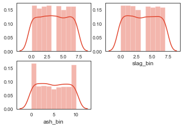

```python
#Try putting age, slag, and ash into bins as there are too many 0s.
figure = plt.figure()
X1['age_bin'],bin1 = pd.qcut(df['age'].rank(method='first'), q=8, labels=range(8), retbins=True)
X1['slag_bin'],bin2 = pd.qcut(df['slag'].rank(method='first'), q=8, labels=range(8), retbins=True)
X1['ash_bin'],bin3 = pd.qcut(df['ash'].rank(method='first'), q=11, labels=range(11), retbins=True)
figure.add_subplot(2, 2, 1)
sns.distplot(X1['age_bin'])
figure.add_subplot(2, 2, 2)
sns.distplot(X1['slag_bin'])
figure.add_subplot(2, 2, 3)
sns.distplot(X1['ash_bin'])
plt.show()
```

```python
# X2 = X1.drop(['ash','slag','age'], axis =1)
# for col in ['ash_bin']:
# #             ,'slag_bin','age_bin']:
#     X2[col] = X2[col].astype('float')
X2 = X1.drop(['ash_bin','slag_bin','age_bin'], axis =1)
```

> - Binning seems have negative impact on the accuracy of the model

```python
X2.columns
```

```
Index(['cement', 'slag', 'ash', 'water', 'superplastic', 'coarseagg',
       'fineagg', 'age'],
      dtype='object')
```

```python
X2
```

|  | cement | slag | ash | water | superplastic | coarseagg | fineagg | age |
| --- | --- | --- | --- | --- | --- | --- | --- | --- |
| 0 | 141.30 | 212.00 | 121.40 | 203.50 | 9.00 | 971.80 | 748.50 | 28.00 |
| 1 | 168.90 | 42.20 | 124.30 | 158.30 | 10.80 | 1,080.80 | 796.20 | 14.00 |
| 2 | 250.00 | 0.00 | 95.70 | 187.40 | 5.50 | 956.90 | 861.20 | 28.00 |
| 3 | 266.00 | 114.00 | 121.40 | 228.00 | 9.00 | 932.00 | 670.00 | 28.00 |
| 4 | 154.80 | 183.40 | 121.40 | 193.30 | 9.10 | 1,047.40 | 696.70 | 28.00 |
| ... | ... | ... | ... | ... | ... | ... | ... | ... |
| 1000 | 135.00 | 0.00 | 166.00 | 180.00 | 10.00 | 961.00 | 805.00 | 28.00 |
| 1001 | 531.30 | 0.00 | 121.40 | 141.80 | 28.20 | 852.10 | 893.70 | 3.00 |
| 1002 | 276.40 | 116.00 | 90.30 | 179.60 | 8.90 | 870.10 | 768.30 | 28.00 |
| 1003 | 342.00 | 38.00 | 121.40 | 228.00 | 9.00 | 932.00 | 670.00 | 270.00 |
| 1004 | 540.00 | 0.00 | 121.40 | 173.00 | 9.00 | 1,125.00 | 613.00 | 7.00 |

1005 rows × 8 columns

```python
X2.describe().T
```

|  | count | mean | std | min | 25% | 50% | 75% | max |
| --- | --- | --- | --- | --- | --- | --- | --- | --- |
| cement | 1,005.00 | 278.63 | 104.34 | 102.00 | 190.70 | 265.00 | 349.00 | 540.00 |
| slag | 1,005.00 | 72.04 | 86.17 | 0.00 | 0.00 | 20.00 | 142.50 | 359.40 |
| ash | 1,005.00 | 120.89 | 22.88 | 24.50 | 121.40 | 121.40 | 121.40 | 200.10 |
| water | 1,005.00 | 182.08 | 21.34 | 121.80 | 166.60 | 185.70 | 192.90 | 247.00 |
| superplastic | 1,005.00 | 9.42 | 3.63 | 1.70 | 8.10 | 9.00 | 10.00 | 32.20 |
| coarseagg | 1,005.00 | 974.38 | 77.58 | 801.00 | 932.00 | 968.00 | 1,031.00 | 1,145.00 |
| fineagg | 1,005.00 | 772.69 | 80.34 | 594.00 | 724.30 | 780.00 | 822.20 | 992.60 |
| age | 1,005.00 | 45.86 | 63.73 | 1.00 | 7.00 | 28.00 | 56.00 | 365.00 |

> - Double checking to see if there are not many outliers or null values. Slag still seems to have 1st quartile as 0.

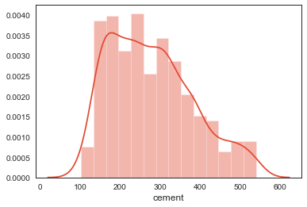

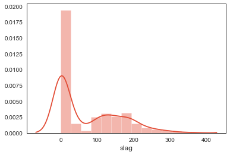

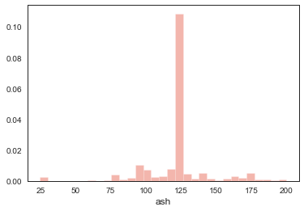

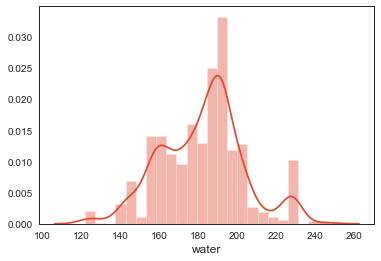

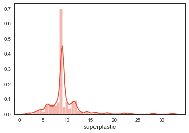

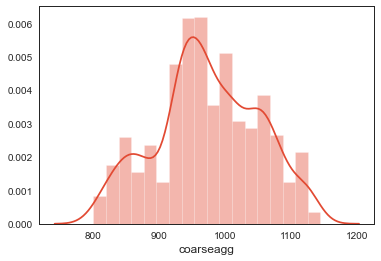

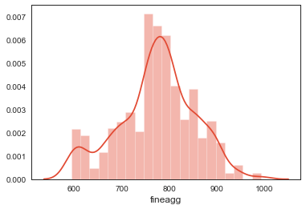

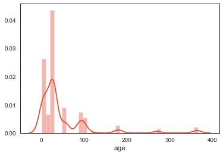

```python
for col in X2.columns:
    ax = sns.distplot(X2[col])
    plt.show()
```

> - Ash, water, superplastic seems to be more normally distributed after imputation.

#### Test Train Split

```python
from sklearn.model_selection import train_test_split
X_train, X_test, y_train, y_test = train_test_split(X2, Y, test_size = 0.30, random_state=0)
```

#### Linear Model

```python
#Run Models on Regular Test/Train Split:
#Run Models on Regular Test/Train Split:
df_reg = pd.DataFrame()
#Linear Regression
regression_model = LinearRegression()
regression_model.fit(X_train, y_train)
y_pred = regression_model.predict(X_test)
df_reg.loc[0,'Name'] = 'Liner Regression'
df_reg.loc[0,'Train Score'] = regression_model.score(X_train, y_train)
df_reg.loc[0,'Test Score'] = regression_model.score(X_test, y_test)
df_reg.loc[0,'Mean Squared Error'] = mean_squared_error(y_pred,y_test)
#Lasso
lasso = Lasso(alpha=0.2)
lasso.fit(X_train,y_train)
y_pred = lasso.predict(X_test)
df_reg.loc[1,'Name'] = 'Lasso Regression'
df_reg.loc[1,'Train Score'] = lasso.score(X_train, y_train)
df_reg.loc[1,'Test Score'] = lasso.score(X_test, y_test)
df_reg.loc[1,'Mean Squared Error'] = mean_squared_error(y_pred,y_test)
#Ridge
ridge = Ridge(alpha=.3)
ridge.fit(X_train,y_train)
y_pred = ridge.predict(X_test)
df_reg.loc[2,'Name'] = 'Ridge Regression'
df_reg.loc[2,'Train Score'] = ridge.score(X_train, y_train)
df_reg.loc[2,'Test Score'] = ridge.score(X_test, y_test)
df_reg.loc[2,'Mean Squared Error'] = mean_squared_error(y_pred,y_test)
#Random Forest
random_model = RandomForestRegressor(n_estimators=200, random_state=7)
random_model.fit(X_train,y_train)
y_pred = random_model.predict(X_test)
df_reg.loc[3,'Name'] = 'Random Forest'
df_reg.loc[3,'Train Score'] = random_model.score(X_train, y_train)
df_reg.loc[3,'Test Score'] = random_model.score(X_test, y_test)
df_reg.loc[3,'Mean Squared Error'] = mean_squared_error(y_pred,y_test)
#Bagging
bagging_model = BaggingRegressor(n_estimators=200, max_samples= .7, bootstrap=True, oob_score=True, random_state=7)
bagging_model.fit(X_train, y_train)
y_pred = bagging_model.predict(X_test)
df_reg.loc[4,'Name'] = 'Bagging'
df_reg.loc[4,'Train Score'] = bagging_model.score(X_train, y_train)
df_reg.loc[4,'Test Score'] = bagging_model.score(X_test, y_test)
df_reg.loc[4,'Mean Squared Error'] = mean_squared_error(y_pred,y_test)
#Boosting
boosting_model = GradientBoostingRegressor(n_estimators = 200, learning_rate = 0.1, random_state=7)
boosting_model.fit(X_train, y_train)
y_pred = boosting_model.predict(X_test)
df_reg.loc[5,'Name'] = 'Boosting'
df_reg.loc[5,'Train Score'] = boosting_model.score(X_train, y_train)
df_reg.loc[5,'Test Score'] = boosting_model.score(X_test, y_test)
df_reg.loc[5,'Mean Squared Error'] = mean_squared_error(y_pred,y_test)
df_reg
```

|  | Name | Train Score | Test Score | Mean Squared Error |
| --- | --- | --- | --- | --- |
| 0 | Liner Regression | 0.60 | 0.61 | 98.08 |
| 1 | Lasso Regression | 0.60 | 0.61 | 98.14 |
| 2 | Ridge Regression | 0.60 | 0.61 | 98.08 |
| 3 | Random Forest | 0.98 | 0.90 | 26.65 |
| 4 | Bagging | 0.97 | 0.89 | 29.01 |
| 5 | Boosting | 0.97 | 0.91 | 23.51 |

> - Linear Regression, Lasso, and Ridge have lower accuracy and higher error, Random Forest, Bagging, and Boosting seem to perform better with lower errors

#### Model Complexity

```python
from sklearn.preprocessing import PolynomialFeatures
poly = PolynomialFeatures(degree = 2, interaction_only=True)
X_poly = poly.fit_transform(X2)
X_train, X_test, y_train, y_test = train_test_split(X_poly, Y, test_size=0.30, random_state=0)
X_train.shape
```

```
(703, 37)
```

#### Quadratic Model

```python
#Run Models on Regular Test/Train Split:
df_reg = pd.DataFrame()
#Linear Regression
regression_model = LinearRegression()
regression_model.fit(X_train, y_train)
y_pred = regression_model.predict(X_test)
df_reg.loc[0,'Name'] = 'Liner Regression'
df_reg.loc[0,'Train Score'] = regression_model.score(X_train, y_train)
df_reg.loc[0,'Test Score'] = regression_model.score(X_test, y_test)
df_reg.loc[0,'Mean Squared Error'] = mean_squared_error(y_pred,y_test)
#Lasso
lasso = Lasso(alpha=0.2)
lasso.fit(X_train,y_train)
y_pred = lasso.predict(X_test)
df_reg.loc[1,'Name'] = 'Lasso Regression'
df_reg.loc[1,'Train Score'] = lasso.score(X_train, y_train)
df_reg.loc[1,'Test Score'] = lasso.score(X_test, y_test)
df_reg.loc[1,'Mean Squared Error'] = mean_squared_error(y_pred,y_test)
#Ridge
ridge = Ridge(alpha=.3)
ridge.fit(X_train,y_train)
y_pred = ridge.predict(X_test)
df_reg.loc[2,'Name'] = 'Ridge Regression'
df_reg.loc[2,'Train Score'] = ridge.score(X_train, y_train)
df_reg.loc[2,'Test Score'] = ridge.score(X_test, y_test)
df_reg.loc[2,'Mean Squared Error'] = mean_squared_error(y_pred,y_test)
#Random Forest
random_model = RandomForestRegressor(n_estimators=200, random_state=7)
random_model.fit(X_train,y_train)
y_pred = random_model.predict(X_test)
df_reg.loc[3,'Name'] = 'Random Forest'
df_reg.loc[3,'Train Score'] = random_model.score(X_train, y_train)
df_reg.loc[3,'Test Score'] = random_model.score(X_test, y_test)
df_reg.loc[3,'Mean Squared Error'] = mean_squared_error(y_pred,y_test)
#Bagging
bagging_model = BaggingRegressor(n_estimators=200, max_samples= .7, bootstrap=True, oob_score=True, random_state=7)
bagging_model.fit(X_train, y_train)
y_pred = bagging_model.predict(X_test)
df_reg.loc[4,'Name'] = 'Bagging'
df_reg.loc[4,'Train Score'] = bagging_model.score(X_train, y_train)
df_reg.loc[4,'Test Score'] = bagging_model.score(X_test, y_test)
df_reg.loc[4,'Mean Squared Error'] = mean_squared_error(y_pred,y_test)
#Boosting
boosting_model = GradientBoostingRegressor(n_estimators = 200, learning_rate = 0.1, random_state=7)
boosting_model.fit(X_train, y_train)
y_pred = boosting_model.predict(X_test)
df_reg.loc[5,'Name'] = 'Boosting'
df_reg.loc[5,'Train Score'] = boosting_model.score(X_train, y_train)
df_reg.loc[5,'Test Score'] = boosting_model.score(X_test, y_test)
df_reg.loc[5,'Mean Squared Error'] = mean_squared_error(y_pred,y_test)
df_reg
```

|  | Name | Train Score | Test Score | Mean Squared Error |
| --- | --- | --- | --- | --- |
| 0 | Liner Regression | 0.74 | 0.63 | 95.25 |
| 1 | Lasso Regression | 0.71 | 0.62 | 96.34 |
| 2 | Ridge Regression | 0.74 | 0.63 | 95.26 |
| 3 | Random Forest | 0.98 | 0.89 | 28.59 |
| 4 | Bagging | 0.97 | 0.88 | 30.32 |
| 5 | Boosting | 0.98 | 0.91 | 23.40 |

> - After comparing Linear and Quadratic Model. Quadratic and Linear models are performing very similarly. Quadratic model is slightly better especially on Linear, Lasso, and Ridge

#### Highlights

> - Quadratic Model is performing slightly better
> - Bins are not working
> - Imputation helped data become more normalized

### Model Tuning

#### KFold Cross Validation Model

```python
df_reg = pd.DataFrame()
num_folds = 22
seed = 22
kfold = KFold(n_splits=num_folds, random_state=seed)
# Linear Regression
regression_model = LinearRegression()
regression_model.fit(X_train, y_train)
regression_cv = cross_val_score(regression_model, X2,Y, cv=kfold)
df_reg.loc[0,'Name'] = 'Liner Regression'
df_reg.loc[0,'Score Mean'] = regression_cv.mean()
df_reg.loc[0,'Standard Deviation'] = regression_cv.std()
#Lasso
lasso = Lasso(alpha=0.2)
lasso.fit(X_train,y_train)
lasso_cv = cross_val_score(lasso, X2,Y, cv=kfold)
df_reg.loc[1,'Name'] = 'Lasso Regression'
df_reg.loc[1,'Score Mean'] = lasso_cv.mean()
df_reg.loc[1,'Standard Deviation'] = lasso_cv.std()
#Ridge
ridge = Ridge(alpha=.3)
ridge.fit(X_train,y_train)
ridge_cv = cross_val_score(ridge, X2,Y, cv=kfold)
df_reg.loc[2,'Name'] = 'Ridge Regression'
df_reg.loc[2,'Score Mean'] = ridge_cv.mean()
df_reg.loc[2,'Standard Deviation'] = ridge_cv.std()
#Random Forest
random_model = RandomForestRegressor(n_estimators=200, random_state=7)
random_model.fit(X_train,y_train)
random_cv = cross_val_score(random_model, X2,Y, cv=kfold)
df_reg.loc[3,'Name'] = 'Random Forest'
df_reg.loc[3,'Score Mean'] = random_cv.mean()
df_reg.loc[3,'Standard Deviation'] = random_cv.std()
#Bagging
bagging_model = BaggingRegressor(n_estimators=200, max_samples= .7, bootstrap=True, oob_score=True, random_state=7)
bagging_model.fit(X_train, y_train)
bagging_cv = cross_val_score(bagging_model, X2, Y, cv=kfold)
df_reg.loc[4,'Name'] = 'Bagging'
df_reg.loc[4,'Score Mean'] = bagging_cv.mean()
df_reg.loc[4,'Standard Deviation'] = bagging_cv.std()
#Boosting
boosting_model = GradientBoostingRegressor(n_estimators = 200, learning_rate = 0.1, random_state=7)
boosting_model.fit(X_train, y_train)
boosting_cv = cross_val_score(boosting_model, X2, Y, cv=kfold)
df_reg.loc[5,'Name'] = 'Boosting'
df_reg.loc[5,'Score Mean'] = boosting_cv.mean()
df_reg.loc[5,'Standard Deviation'] = boosting_cv.std()
#Extra Tree Regressor
etr_ = ExtraTreesRegressor(n_estimators = 200, random_state=7)
etr.fit(X_train, y_train)
etts = cross_val_score(etr, X2, Y, cv=kfold)
df_reg.loc[6,'Name'] = 'ExtraTree Regression'
df_reg.loc[6,'Score Mean'] = etts.mean()
df_reg.loc[6,'Standard Deviation'] = etts.std()
df_reg
```

|  | Name | Score Mean | Standard Deviation |
| --- | --- | --- | --- |
| 0 | Liner Regression | 0.56 | 0.15 |
| 1 | Lasso Regression | 0.56 | 0.15 |
| 2 | Ridge Regression | 0.56 | 0.15 |
| 3 | Random Forest | 0.91 | 0.06 |
| 4 | Bagging | 0.90 | 0.05 |
| 5 | Boosting | 0.92 | 0.03 |
| 6 | ExtraTree Regression | 0.91 | 0.07 |

> - This method has very good scores for Random Forest, Bagging, Boosting, and Extra Tree Regression. This is more accurate prediction of how the model would behave in Production

#### Grid Search

```python
#Split Train further into Train and Validation for hyper parameter Tuning
X_train, X_val, y_train, y_val = train_test_split(X_train, y_train, test_size = 0.30, random_state=3)
```

##### Use Pipelines, Standard Scaler, Validation

```python
#Grid Search for Bagging Regressor
pipe_bgrgr = Pipeline([('scl', StandardScaler()),('ettr',BaggingRegressor())])
param_grid_bgrgr = {'ettr__n_estimators':[200,250,300],'ettr__max_samples':[0.7,0.8,0.9], 'ettr__bootstrap':[True,False],
                  'ettr__oob_score':[True,False], 'ettr__random_state':[10]}
#'svc__random_state':[7,10,12,18,100]
grid_bg = GridSearchCV( pipe_bgrgr ,  param_grid = param_grid_bgrgr, cv = 22)
grid_bg.fit(X_train, y_train)

#Grid Search for Extra Tree Regressor
pipe_etr = Pipeline([('scl', StandardScaler()),('etrg',ExtraTreesRegressor())])
param_grid_etr = {'etrg__n_estimators':[200,250],'etrg__max_samples':[.7,0.8,0.9], 'etrg__bootstrap':[True,False],
                  'etrg__oob_score':[True,False], 'etrg__random_state':[10]}
#'svc__random_state':[7,10,12,18,100]
grid_tr = GridSearchCV( pipe_etr ,  param_grid = param_grid_etr, cv = 22)
grid_tr.fit(X_train, y_train)

#Grid Search for Gradient Boosting Regressor
pipe_gbr = Pipeline([('svc', GradientBoostingRegressor())])
param_grid_gbr = {'svc__random_state':[10],'svc__n_estimators':[250],
                  'svc__ccp_alpha': [0.0001,0.001], 'svc__alpha': [0.0001,0.001],
                  'svc__max_depth': [2,3], 'svc__learning_rate' : [0.2,0.3]}
#'svc__random_state':[7,10,12,18,100],
grid_gbr = GridSearchCV( pipe_gbr , param_grid = param_grid_gbr, cv = 20)
grid_gbr.fit(X_train, y_train)
```

```
GridSearchCV(cv=20, error_score=nan,
             estimator=Pipeline(memory=None,
                                steps=[('svc',
                                        GradientBoostingRegressor(alpha=0.9,
                                                                  ccp_alpha=0.0,
                                                                  criterion='friedman_mse',
                                                                  init=None,
                                                                  learning_rate=0.1,
                                                                  loss='ls',
                                                                  max_depth=3,
                                                                  max_features=None,
                                                                  max_leaf_nodes=None,
                                                                  min_impurity_decrease=0.0,
                                                                  min_impurity_split=None,
                                                                  min_samples_leaf=1,
                                                                  min_samples_split=2,
                                                                  min_weight_fractio...
                                                                  validation_fraction=0.1,
                                                                  verbose=0,
                                                                  warm_start=False))],
                                verbose=False),
             iid='deprecated', n_jobs=None,
             param_grid={'svc__alpha': [0.0001, 0.001],
                         'svc__ccp_alpha': [0.0001, 0.001],
                         'svc__learning_rate': [0.2, 0.3],
                         'svc__max_depth': [2, 3], 'svc__n_estimators': [250],
                         'svc__random_state': [10]},
             pre_dispatch='2*n_jobs', refit=True, return_train_score=False,
             scoring=None, verbose=0)
```

> - Tried with random states 7,10,12,18,100.
> - Tried with cv values between 20 - 25
> - Tried with dimensionality reduction but that seems to reduce accuracy and overall score

```python
df_reg = pd.DataFrame()
df_reg.loc[0,'Name'] = 'Grid Search for Bagging'
df_reg.loc[0,'Best cross-validation accuracy'] = "{:.2f}".format( grid_bg.best_score_)
df_reg.loc[0,'Validation set accuracy'] = "{:.2f}".format( grid_bg.score( X_val, y_val))
df_reg.loc[0,'Test set accuracy'] = "{:.2f}".format( grid_bg.score( X_test, y_test))

df_reg.loc[1,'Name'] = 'Grid Search for ExtraTree Regression'
df_reg.loc[1,'Best cross-validation accuracy'] = "{:.2f}". format( grid_tr.best_score_)
df_reg.loc[1,'Validation set accuracy'] = "{:.2f}". format( grid_tr.score( X_val, y_val))
df_reg.loc[1,'Test set accuracy'] = "{:.2f}". format( grid_tr.score( X_test, y_test))

df_reg.loc[2,'Name'] = 'Grid Search for Boosting'
df_reg.loc[2,'Best cross-validation accuracy'] = "{:.2f}". format( grid_gbr.best_score_)
df_reg.loc[2,'Validation set accuracy'] = "{:.2f}". format( grid_gbr.score( X_val, y_val))
df_reg.loc[2,'Test set accuracy'] = "{:.2f}". format( grid_gbr.score( X_test, y_test))

df_reg
```

|  | Name | Best cross-validation accuracy | Validation set accuracy | Test set accuracy |
| --- | --- | --- | --- | --- |
| 0 | Grid Search for Bagging | 0.85 | 0.87 | 0.86 |
| 1 | Grid Search for ExtraTree Regression | 0.87 | 0.89 | 0.89 |
| 2 | Grid Search for Boosting | 0.88 | 0.92 | 0.91 |

> - Boosting is the clear winner in gradient search with accuracy scores around 90%

```python
#Print Hyperparameters chosen
print("Bagging:",grid_bg.best_params_)
print("ExtraTree:", grid_tr.best_params_)
print("Boosting:", grid_gbr.best_params_)
```

```
Bagging: {'ettr__bootstrap': True, 'ettr__max_samples': 0.9, 'ettr__n_estimators': 300, 'ettr__oob_score': True, 'ettr__random_state': 10}
ExtraTree: {'etrg__bootstrap': False, 'etrg__max_samples': 0.7, 'etrg__n_estimators': 250, 'etrg__oob_score': False, 'etrg__random_state': 10}
Boosting: {'svc__alpha': 0.0001, 'svc__ccp_alpha': 0.001, 'svc__learning_rate': 0.2, 'svc__max_depth': 2, 'svc__n_estimators': 250, 'svc__random_state': 10}
```

> - The more estimators provided, the algorithm chooses the highes ones.

### Conclusion

#### Problem statement: Criteria of success is to predict concrete strength with an accuracy of more than 85%.

> - The accuracy of ensemble models are better than simple linear models models and have an accuracy of more than 85% in most cases.
> - Quadratic Models seem to be doing better than Linear Models
> - Random Forest, Bagging, Boosting, and ExtraTree Regression all have a high accuracy for cross validation scores, and lower standard deviation i.e. the values are not that far apart and the model is not an overfit.
> - For Grid Search, Boosting seems to be the clear winner with accuracy scores around 90%